# Measuring Stock Market Risk

Tori Green

#Import Dataset

```r
Beta_1_ <- read.csv("~/Downloads/Beta (1).csv")
```

```r
stock1 <- Beta_1_
```

#Display the 1st few rows of stock1

```r
head(stock1)
```

```
##    Month Microsoft Exxon.Mobil Caterpillar Johnson...Johnson McDonald.s
## 1 Jan-03  -0.08201    -0.02261    -0.03040          -0.00186   -0.11443
## 2 Feb-03   0.00211     0.00293     0.06867          -0.01781   -0.04424
## 3 Mar-03   0.02152     0.02734     0.04681           0.10334    0.06245
## 4 Apr-03   0.05576     0.00715     0.07622          -0.02609    0.18257
## 5 May-03  -0.03717     0.04119    -0.00856          -0.03141    0.09532
## 6 Jun-03   0.04185    -0.01346     0.06731          -0.04876    0.17779
##    Sandisk Qualcomm Procter...Gamble   S.P.500
## 1 -0.24867  0.03490         0.000465 -0.027415
## 2  0.09363 -0.08178        -0.043356 -0.017004
## 3  0.00839  0.04251         0.087833  0.008358
## 4  0.43876 -0.11444         0.013588  0.081044
## 5  0.50165  0.05395         0.021925  0.050899
## 6  0.11640  0.07124        -0.028752  0.011322
```

```r
str(stock1)
```

```
## 'data.frame':    36 obs. of  10 variables:
##  $ Month            : Factor w/ 36 levels "Apr-03","Apr-04",..: 13 10 22 1 25 19 16 4 34 31 ...
##  $ Microsoft        : num  -0.08201 0.00211 0.02152 0.05576 -0.03717 ...
##  $ Exxon.Mobil      : num  -0.02261 0.00293 0.02734 0.00715 0.04119 ...
##  $ Caterpillar      : num  -0.0304 0.06867 0.04681 0.07622 -0.00856 ...
##  $ Johnson...Johnson: num  -0.00186 -0.01781 0.10334 -0.02609 -0.03141 ...
##  $ McDonald.s       : num  -0.1144 -0.0442 0.0624 0.1826 0.0953 ...
##  $ Sandisk          : num  -0.24867 0.09363 0.00839 0.43876 0.50165 ...
##  $ Qualcomm         : num  0.0349 -0.0818 0.0425 -0.1144 0.0539 ...
##  $ Procter...Gamble : num  0.000465 -0.043356 0.087833 0.013588 0.021925 ...
##  $ S.P.500          : num  -0.02741 -0.017 0.00836 0.08104 0.0509 ...
```

## A

##The descriptive statistics for each individual stock are below. The average rate of return for Sandisk and Caterpillar are highest with means of 0.06926 and 0.03010 and medians of 0.07414 and 0.04081 respectively.

##Microsoft has the lowest average rate of return with a mean of 0.005026 and median of 0.004000 respectively. However, Johnson & Johnson has a negative median value of -0.001475.

##Based on the calculated standard deviations, Sandisk has the most volatility, with a standard deviation of 0.19539743, followed by Qualcomm (standard deviation of 0.08618695) and Caterpillar (standard deviation of 0.06856325).

##Procter & Gamble and Johnson & Johnson have the lowest volatility based on their standard deviations of 0.03706675 and 0.03486600 respectively.

#View Descriptive Statistics

```r
summary(stock1)
```

```
##      Month      Microsoft          Exxon.Mobil        Caterpillar
##  Apr-03 : 1   Min.   :-0.082010   Min.   :-0.11646   Min.   :-0.10060
##  Apr-04 : 1   1st Qu.:-0.037648   1st Qu.:-0.00926   1st Qu.:-0.03042
##  Apr-05 : 1   Median : 0.004000   Median : 0.01278   Median : 0.04081
##  Aug-03 : 1   Mean   : 0.005026   Mean   : 0.01664   Mean   : 0.03010
##  Aug-04 : 1   3rd Qu.: 0.043075   3rd Qu.: 0.03911   3rd Qu.: 0.06871
##  Aug-05 : 1   Max.   : 0.088830   Max.   : 0.23217   Max.   : 0.21847
##  (Other):30
##  Johnson...Johnson     McDonald.s          Sandisk
##  Min.   :-0.059170   Min.   :-0.11443   Min.   :-0.28331
##  1st Qu.:-0.017570   1st Qu.:-0.02685   1st Qu.:-0.06935
##  Median :-0.001475   Median : 0.03701   Median : 0.07414
##  Mean   : 0.005296   Mean   : 0.02447   Mean   : 0.06926
##  3rd Qu.: 0.026353   3rd Qu.: 0.05877   3rd Qu.: 0.16625
##  Max.   : 0.103340   Max.   : 0.18257   Max.   : 0.50165
##
##     Qualcomm        Procter...Gamble      S.P.500
##  Min.   :-0.12170   Min.   :-0.05365   Min.   :-0.03429
##  1st Qu.:-0.04827   1st Qu.:-0.01240   1st Qu.:-0.01305
##  Median : 0.03871   Median : 0.01333   Median : 0.01034
##  Mean   : 0.02836   Mean   : 0.01059   Mean   : 0.01010
##  3rd Qu.: 0.07992   3rd Qu.: 0.02772   3rd Qu.: 0.02167
##  Max.   : 0.21055   Max.   : 0.08783   Max.   : 0.08104
##
```

#Calculate the Standard Deviation for each of the individual stocks and the stock market

```r
sdstock <-apply(stock1[,2:10],2,sd)
print(sdstock)
```

```
##         Microsoft       Exxon.Mobil       Caterpillar Johnson...Johnson
##        0.04537158        0.05534009        0.06856325        0.03486600
##        McDonald.s           Sandisk          Qualcomm  Procter...Gamble
##        0.06809637        0.19539743        0.08618695        0.03706675
##           S.P.500
##        0.02632935
```

#Correlation between variables

```r
cor_data <- stock1[,2:length(stock1)]
round(cor(cor_data),2)
```

```
##                   Microsoft Exxon.Mobil Caterpillar Johnson...Johnson
## Microsoft              1.00        0.06        0.33              0.15
## Exxon.Mobil            0.06        1.00        0.36              0.14
## Caterpillar            0.33        0.36        1.00             -0.14
## Johnson...Johnson      0.15        0.14       -0.14              1.00
## McDonald.s             0.30        0.14        0.38             -0.17
## Sandisk               -0.11       -0.08        0.34             -0.44
## Qualcomm               0.10        0.27        0.39              0.12
## Procter...Gamble       0.04        0.12        0.20              0.43
## S.P.500                0.27        0.35        0.57              0.01
##                   McDonald.s Sandisk Qualcomm Procter...Gamble S.P.500
## Microsoft               0.30   -0.11     0.10             0.04    0.27
## Exxon.Mobil             0.14   -0.08     0.27             0.12    0.35
## Caterpillar             0.38    0.34     0.39             0.20    0.57
## Johnson...Johnson      -0.17   -0.44     0.12             0.43    0.01
## McDonald.s              1.00    0.50     0.23             0.22    0.58
## Sandisk                 0.50    1.00    -0.06             0.10    0.35
## Qualcomm                0.23   -0.06     1.00             0.54    0.43
## Procter...Gamble        0.22    0.10     0.54             1.00    0.36
## S.P.500                 0.58    0.35     0.43             0.36    1.00
```

#Plot

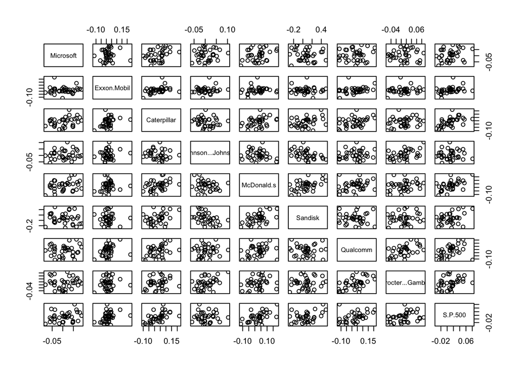

```r
pairs(cor_data)
```

## B

##The stocks that could be expected to perform best in an up market are Sandisk, McDonald’s, Caterpillar, and Qualcomm. ##They have betas greater than 1. Therefore, a 1 unit increase in the rate of return for the market will result in an increase of 2.60484 for Sandisk, 1.503201 for McDonald’s, 1.49320 for Caterpillar and 1.41389 for Qualcomm. ##On the other hand, I would expect Johnson & Johnson to hold their value best in a down market because its beta value is 0.008757. This low beta value means that this stock is not as volatile as the S&P 500 and therefore when the market is down, this will have a minimal effect on this stock’s return.

## C

##The coefficient of determination, the Multiple R-squared value, explains how much of the individual stock’s return can be explained by the market, S&P 500. ##Values that are closer to a value of 1 indicate that the regression relationship between the individual stock and the market is very strong. ##Johnson & Johnson has the smallest r-squared value at 4.373e-05. This value is very close to 0 indicating that there is no relationship. ##The other remaining r-squared values range from 0.07075 to 0.3378. From these values we can conclude that not much of the variability can be explained by the S & P 500.

##Null Hypothesis: b(sub 1) = 0 ##Alternate Hypothesis: b (sub 1) does not = 0

##Johnson and Johnson’s 95% confidence interval of -0.45276 - 0.47028 contains the value of zero, from which we can conclude that there is no significant relationship between it and the S & P 500.

#Perform simple linear regression and confidence intervals for each individual stock

```r
lr1 <-lm(Microsoft ~ S.P.500, data=stock1)
summary(lr1)
```

```
##
## Call:
## lm(formula = Microsoft ~ S.P.500, data = stock1)
##
## Residuals:
##       Min        1Q    Median        3Q       Max
## -0.079550 -0.038259  0.005656  0.025712  0.080186
##
## Coefficients:
##              Estimate Std. Error t value Pr(>|t|)
## (Intercept) 0.0003984  0.0079355   0.050    0.960
## S.P.500     0.4583448  0.2848864   1.609    0.117
##
## Residual standard error: 0.04438 on 34 degrees of freedom
## Multiple R-squared:  0.07075,    Adjusted R-squared:  0.04341
## F-statistic: 2.588 on 1 and 34 DF,  p-value: 0.1169
```

```r
confint(lr1)
```

```
##                   2.5 %     97.5 %
## (Intercept) -0.01572838 0.01652525
## S.P.500     -0.12061396 1.03730357
```

```r
lr2 <-lm(Exxon.Mobil ~ S.P.500, data=stock1)
summary(lr2)
```

```
##
## Call:
## lm(formula = Exxon.Mobil ~ S.P.500, data = stock1)
##
## Residuals:
##       Min        1Q    Median        3Q       Max
## -0.112751 -0.030479 -0.003176  0.017337  0.209095
##
## Coefficients:
##             Estimate Std. Error t value Pr(>|t|)
## (Intercept) 0.009259   0.009414   0.983   0.3323
## S.P.500     0.730907   0.337966   2.163   0.0377 *
## ---
## Signif. codes:  0 '***' 0.001 '**' 0.01 '*' 0.05 '.' 0.1 ' ' 1
##
## Residual standard error: 0.05264 on 34 degrees of freedom
## Multiple R-squared:  0.1209, Adjusted R-squared:  0.09507
## F-statistic: 4.677 on 1 and 34 DF,  p-value: 0.03769
```

```r
confint(lr2)
```

```
##                    2.5 %     97.5 %
## (Intercept) -0.009873006 0.02839003
## S.P.500      0.044078295 1.41773596
```

```r
lr3 <-lm(Caterpillar ~ S.P.500, data=stock1)
summary(lr3)
```

```
##
## Call:
## lm(formula = Caterpillar ~ S.P.500, data = stock1)
##
## Residuals:
##       Min        1Q    Median        3Q       Max
## -0.099586 -0.030686 -0.000617  0.031065  0.179221
##
## Coefficients:
##             Estimate Std. Error t value Pr(>|t|)
## (Intercept)  0.01502    0.01019   1.474 0.149664
## S.P.500      1.49320    0.36588   4.081 0.000256 ***
## ---
## Signif. codes:  0 '***' 0.001 '**' 0.01 '*' 0.05 '.' 0.1 ' ' 1
##
## Residual standard error: 0.05699 on 34 degrees of freedom
## Multiple R-squared:  0.3288, Adjusted R-squared:  0.3091
## F-statistic: 16.66 on 1 and 34 DF,  p-value: 0.0002565
```

```r
confint(lr3)
```

```
##                    2.5 %    97.5 %
## (Intercept) -0.005688687 0.0357345
## S.P.500      0.749650609 2.2367588
```

```r
lr4 <-lm(Johnson...Johnson ~ S.P.500, data=stock1)
summary(lr4)
```

```
##
## Call:
## lm(formula = Johnson...Johnson ~ S.P.500, data = stock1)
##
## Residuals:
##      Min       1Q   Median       3Q      Max
## -0.06423 -0.02289 -0.00657  0.02123  0.09806
##
## Coefficients:
##             Estimate Std. Error t value Pr(>|t|)
## (Intercept) 0.005207   0.006326   0.823    0.416
## S.P.500     0.008757   0.227098   0.039    0.969
##
## Residual standard error: 0.03537 on 34 degrees of freedom
## Multiple R-squared:  4.373e-05,  Adjusted R-squared:  -0.02937
## F-statistic: 0.001487 on 1 and 34 DF,  p-value: 0.9695
```

```r
confint(lr4)
```

```
##                    2.5 %     97.5 %
## (Intercept) -0.007648375 0.01806268
## S.P.500     -0.452761272 0.47027535
```

```r
lr5 <-lm(McDonald.s ~ S.P.500, data=stock1)
summary(lr5)
```

```
##
## Call:
## lm(formula = McDonald.s ~ S.P.500, data = stock1)
##
## Residuals:
##       Min        1Q    Median        3Q       Max
## -0.116819 -0.032679  0.003738  0.032409  0.151472
##
## Coefficients:
##             Estimate Std. Error t value Pr(>|t|)
## (Intercept) 0.009299   0.010054   0.925 0.361536
## S.P.500     1.503201   0.360942   4.165 0.000201 ***
## ---
## Signif. codes:  0 '***' 0.001 '**' 0.01 '*' 0.05 '.' 0.1 ' ' 1
##
## Residual standard error: 0.05622 on 34 degrees of freedom
## Multiple R-squared:  0.3378, Adjusted R-squared:  0.3183
## F-statistic: 17.34 on 1 and 34 DF,  p-value: 0.0002015
```

```r
confint(lr5)
```

```
##                   2.5 %     97.5 %
## (Intercept) -0.01113321 0.02973108
## S.P.500      0.76967931 2.23672306
```

```r
lr6 <-lm(Sandisk ~ S.P.500, data=stock1)
summary(lr6)
```

```
##
## Call:
## lm(formula = Sandisk ~ S.P.500, data = stock1)
##
## Residuals:
##     Min      1Q  Median      3Q     Max
## -0.4180 -0.1311 -0.0068  0.1427  0.3261
##
## Coefficients:
##             Estimate Std. Error t value Pr(>|t|)
## (Intercept)  0.04297    0.03320   1.294   0.2043
## S.P.500      2.60484    1.19176   2.186   0.0358 *
## ---
## Signif. codes:  0 '***' 0.001 '**' 0.01 '*' 0.05 '.' 0.1 ' ' 1
##
## Residual standard error: 0.1856 on 34 degrees of freedom
## Multiple R-squared:  0.1232, Adjusted R-squared:  0.09741
## F-statistic: 4.777 on 1 and 34 DF,  p-value: 0.03582
```

```r
confint(lr6)
```

```
##                   2.5 %    97.5 %
## (Intercept) -0.02449779 0.1104286
## S.P.500      0.18288192 5.0267904
```

```r
lr7 <-lm(Qualcomm ~ S.P.500, data=stock1)
summary(lr7)
```

```
##
## Call:
## lm(formula = Qualcomm ~ S.P.500, data = stock1)
##
## Residuals:
##      Min       1Q   Median       3Q      Max
## -0.24311 -0.05192  0.01269  0.04835  0.13106
##
## Coefficients:
##             Estimate Std. Error t value Pr(>|t|)
## (Intercept)  0.01409    0.01410   0.999  0.32494
## S.P.500      1.41389    0.50632   2.793  0.00852 **
## ---
## Signif. codes:  0 '***' 0.001 '**' 0.01 '*' 0.05 '.' 0.1 ' ' 1
##
## Residual standard error: 0.07887 on 34 degrees of freedom
## Multiple R-squared:  0.1866, Adjusted R-squared:  0.1626
## F-statistic: 7.798 on 1 and 34 DF,  p-value: 0.008524
```

```r
confint(lr7)
```

```
##                   2.5 %     97.5 %
## (Intercept) -0.01457495 0.04274819
## S.P.500      0.38493300 2.44285583
```

```r
lr8 <-lm(Procter...Gamble ~ S.P.500, data=stock1)
summary(lr8)
```

```
##
## Call:
## lm(formula = Procter...Gamble ~ S.P.500, data = stock1)
##
## Residuals:
##       Min        1Q    Median        3Q       Max
## -0.062278 -0.023855  0.000239  0.017048  0.078124
##
## Coefficients:
##             Estimate Std. Error t value Pr(>|t|)
## (Intercept) 0.005475   0.006275   0.873   0.3890
## S.P.500     0.506533   0.225268   2.249   0.0311 *
## ---
## Signif. codes:  0 '***' 0.001 '**' 0.01 '*' 0.05 '.' 0.1 ' ' 1
##
## Residual standard error: 0.03509 on 34 degrees of freedom
## Multiple R-squared:  0.1295, Adjusted R-squared:  0.1039
## F-statistic: 5.056 on 1 and 34 DF,  p-value: 0.03113
```

```r
confint(lr8)
```

```
##                    2.5 %     97.5 %
## (Intercept) -0.007276685 0.01822722
## S.P.500      0.048733261 0.96433321
```